# Why you should order your data

[figure not shown]

Why you should order your data

*A collection of common [dataviz caveats](https://www.data-to-viz.com/caveats.html) by [Data-to-Viz.com](https://www.data-to-viz.com)*

[figure not shown]

By default, most of the data visualization tools will order the groups of your categorical variables using alphabetical order, or using the order of appearance in your input table. It is good practice to think about this order since changing it can add a lot of insight to your graphic.

# Unordered lollipop plot

Let’s start with a lollipop plot showing the [quantity of weapons sold](https://www.data-to-viz.com/story/OneNumOneCat.html) by a few countries. Here each row represents a country and the X-axis shows how many weapons have been sold in 2017. Countries are ordered in alphabetical order by default.

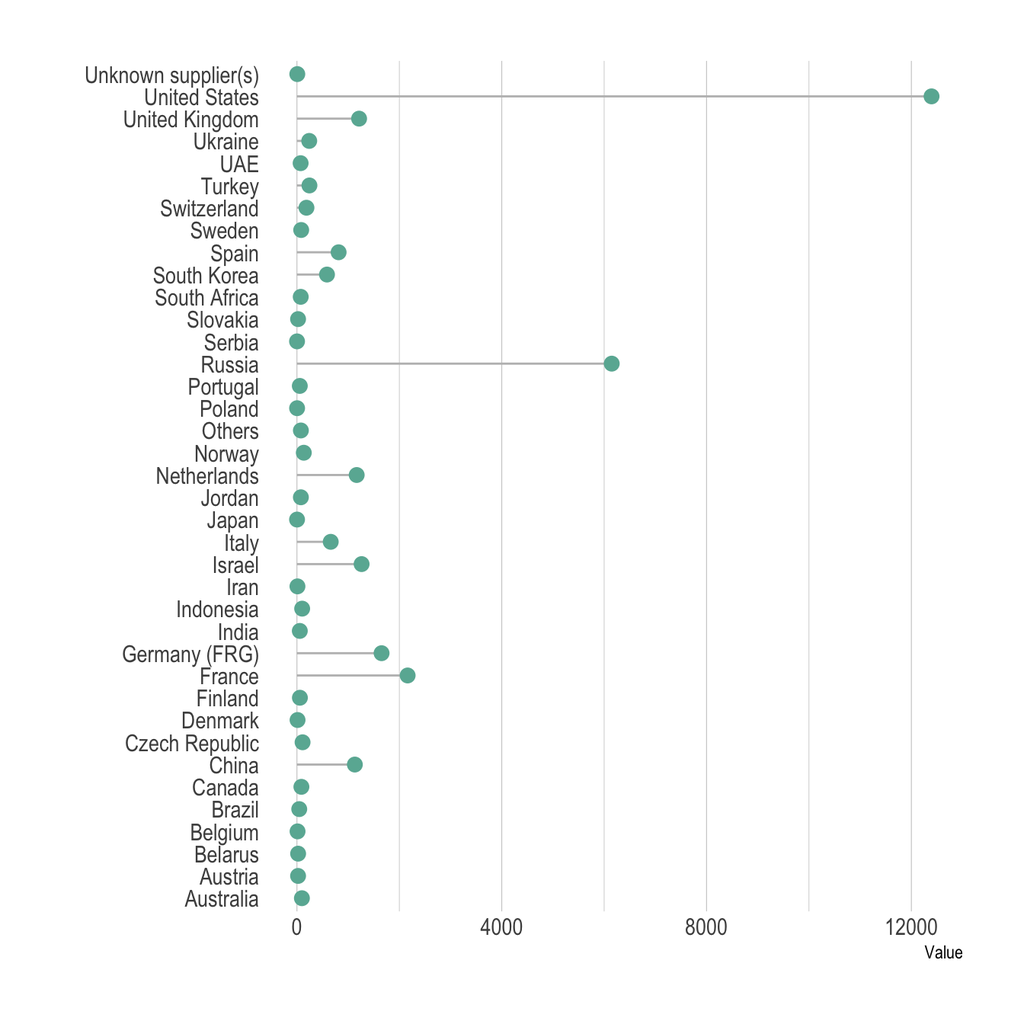

```r
# Libraries
library(tidyverse)
library(hrbrthemes)
library(kableExtra)
options(knitr.table.format = "html")

# Load dataset from github
data <- read.table("https://raw.githubusercontent.com/holtzy/data_to_viz/master/Example_dataset/7_OneCatOneNum.csv", header=TRUE, sep=",")

# Plot
data %>%
  filter(!is.na(Value)) %>%
  ggplot( aes(x=Country, y=Value) ) +
    geom_segment( aes(x=Country ,xend=Country, y=0, yend=Value), color="grey") +
    geom_point(size=3, color="#69b3a2") +
    coord_flip() +
    theme_ipsum() +
    theme(
      panel.grid.minor.y = element_blank(),
      panel.grid.major.y = element_blank(),
      legend.position="none"
    ) +
    xlab("")
```

It is quite obvious that the US and Russia sell many more weapons than the other countries. However, it is quite hard to see the difference between any other countries, and the reader has to go from one to the other to compare them. This is a lot of work and will definitely discard attention to your graphic.

# Reorder it

Instead, let’s make the exact same chart, but reorder each group using their value:

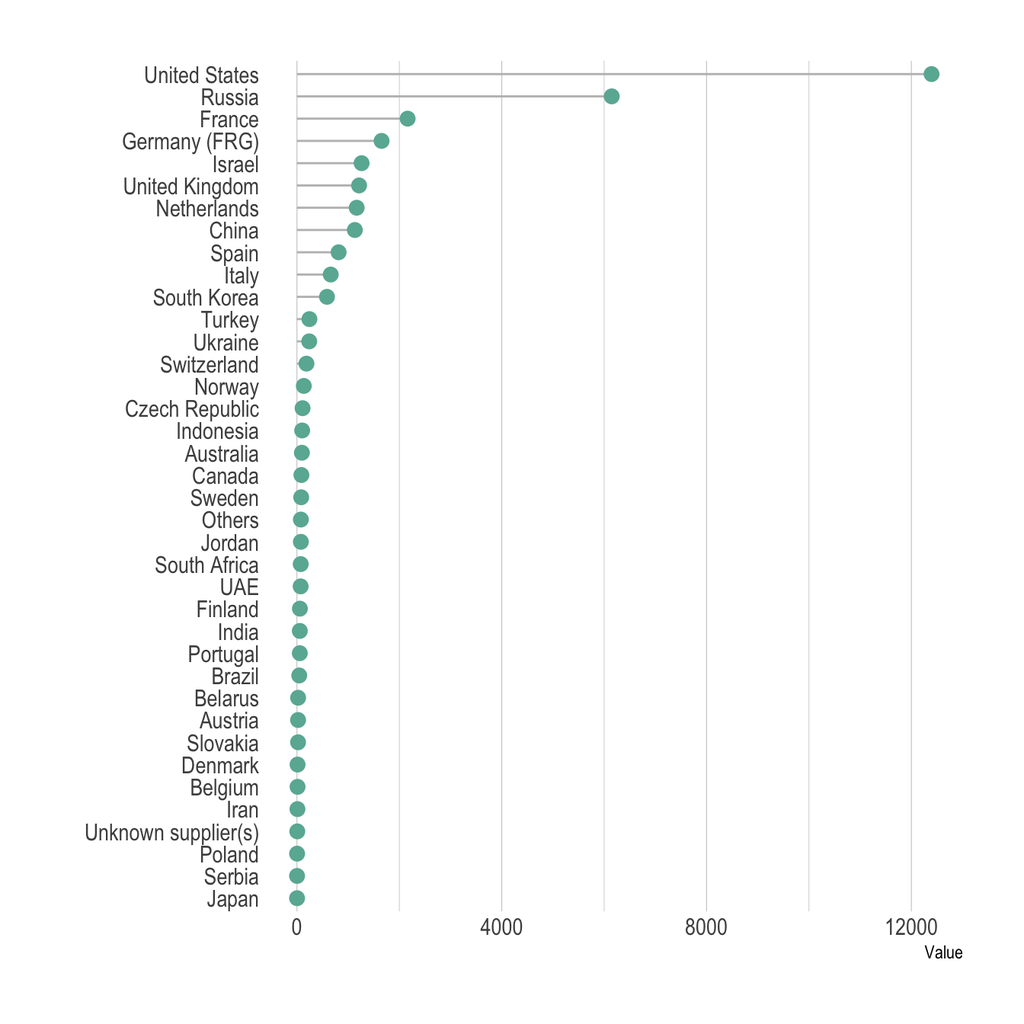

```r
data %>%
  filter(!is.na(Value)) %>%
  arrange(Value) %>%
  mutate(Country=factor(Country, Country)) %>%
  ggplot( aes(x=Country, y=Value) ) +
    geom_segment( aes(x=Country ,xend=Country, y=0, yend=Value), color="grey") +
    geom_point(size=3, color="#69b3a2") +
    coord_flip() +
    theme_ipsum() +
    theme(
      panel.grid.minor.y = element_blank(),
      panel.grid.major.y = element_blank(),
      legend.position="none"
    ) +
    xlab("")
```

The figure is now way more insightful, with France being the third biggest exporting country, followed by Germany, Israel and the UK. Of course, note that it would make sense to normalize this graphic by the population of each country to have more comparable data.

# Conclusion

Reordering your data is an easy step you should always consider when building a chart. Of course, sometimes the order of groups must be set by their features and not their values, like the months of the year, but it’s worth thinking about it.  
*Read more*:

- Have a look to this [#SWD challenge](http://www.storytellingwithdata.com/blog/2018/3/9/bring-on-the-bar-charts) by storytelling with data: you will see that most of the entry ordered their barplot.
- Read more about barplot and lollipop plot
- Have a look to the collection of dataviz pitfalls:

[See the collection](https://www.data-to-viz.com/caveats.html)

# Comments

Any thoughts on this? Want to share another common dataviz pitfall? Disagree? Please drop me a word on [twitter](https://twitter.com/R_Graph_Gallery) or in the comment section below:

A work by [Yan Holtz](https://github.com/holtzy/) for data-to-viz.com